# Model training and testing for Magneticum cluster mass estimates

In this notebook, we load in our relevant data points: masses, luminosities, and morphological parameters. The luminosities are processed in another notebook in order to get core-excised luminosities (15% inner) from the FITS files without background.

We use Ridge Regression, Ordinary Linear Regression, Lasso Regression, and Random Forest Regression.

http://www.magneticum.org/simulations.html

When finalized, generate two separate Jupyter notebooks for the Chandra and eROSITA datasets in order to upload to Github.

## Setup and Preprocessing

```python
%matplotlib inline
import sys
import numpy as np
import matplotlib.pyplot as plt
import pandas as pd
import seaborn as sns
from pandas.plotting import scatter_matrix
import hashlib
from useful_functions.plotter import plot, loglogplot
from random import shuffle
from collections import defaultdict
from sklearn.model_selection import LeaveOneGroupOut, GridSearchCV, RandomizedSearchCV
from sklearn.model_selection import cross_val_score, cross_val_predict
from sklearn.metrics import mean_absolute_error, r2_score
from sklearn.ensemble import RandomForestRegressor, GradientBoostingRegressor, AdaBoostRegressor
from sklearn.linear_model import LinearRegression, Ridge, Lasso, ElasticNet
from sklearn.preprocessing import StandardScaler, RobustScaler
from sklearn.feature_selection import RFE
from astropy.io import fits
import matplotlib.cm as cm
from pathlib import Path
from os.path import expanduser
```

```python
#could we consider adding errors in as features?
#could also consider adding back in some of the features that we threw out for use in Chandra set
#could look into weighting the samples by some metric inversely proportional to errors?
```

```python
#global flags
use_rfe = False
run_rf_cv = True
run_gb_cv = True
scale_features = True
idealized = True
compare_dists = False
instrument = 'chandra'
```

```python
data_dir= Path('../data/')
fig_dir = Path('../figs/')
home_dir = Path(expanduser('~'))
chandra_dir = home_dir / 'magneticum_chandra'
erosita_no_bg_dir = home_dir / 'magneticum_no_bg'

if(compare_dists):
    instrument = 'chandra'
    idealized  = True #overriding anything above

if(idealized):
    if(instrument == 'chandra'):
        param_dir = 'parchandra/'
    else:
        param_dir = 'parameters/' #change this to a folder called "idealized_parameters" or something...
else:
    param_dir = 'parameters1500/'

print("Using %s" %param_dir)

if(instrument == 'chandra'):
    print('Using Chandra')
    use_dir = chandra_dir
elif(instrument == 'erosita'):
    print('Using eROSITA no bg')
    use_dir = erosita_no_bg_dir
```

```
Using parchandra/
Using Chandra
```

### Generating cluster catalog file for Lorenzo

```python
data = np.load(data_dir / (instrument+'_clusterList.npy'))
```

```python
#no scatter
h=0.704 #from Magneticum data
r500_kpc_phys = (data['r500_kpch'] / h) / (1. + data['redshift']) #was originally comoving kpc/h, so divide by h*(1+z)
for_lorenzo = np.column_stack((data['id'],r500_kpc_phys, data['R500_pixel'], data['redshift']))
np.savetxt(data_dir / (instrument+'_cluster_data.dat'),for_lorenzo,fmt=['%d','%f','%f','%f'])
```

### Computing core-excised luminosities

Only would need to be run if we added more clusters, since it computes the core-excised luminosity from the Magneticum luminosity using the no-background mock image.

```python
cluster_directory = use_dir
magneticum_data = np.load(use_dir / 'clusterList.npy')
# make this into a pandas data frame
magneticum_data = pd.DataFrame(data=magneticum_data, columns=magneticum_data.dtype.names)
magneticum_data = magneticum_data.set_index('id')
Nclusters = len(magneticum_data.index)
```

```python
def distance(x1, x2):
    return np.sqrt((x1[0] - x2[0])**2 + (x1[1] - x2[1])**2)
```

```python
#make an array that is 384 x 384, and each element contains the 4 corners in the cell

#so we say that we are within the radius if part of the pixel is within the radius,
#not if its center is within radius
#TODO: we should see how much things differ when we do this...
img_shape_x, img_shape_y = fits.open(cluster_directory / '922603.fits')[0].data.shape
center = np.array([img_shape_x, img_shape_y]) / 2.
cell_dists = np.ndarray((img_shape_x, img_shape_y))
for i in range(0, img_shape_x):
    print(i)
    for j in range(0, img_shape_y):
        #cell_dists[i,j] = distance(center, [i,j])
        cell_dists[i,j] = np.min([distance(center,[i,j]), distance(center,[i+1,j]),
                                  distance(center,[i,j+1]), distance(center,[i+1,j+1])])
```

[output not shown]

[output cut: 2016 more lines]

[output not shown]

```python
def core_excised_Lx(cluster_id, excise_rad_frac):
    dat = fits.open(cluster_directory / ('%d.fits' % cluster_id))[0].data
    r500 = magneticum_data['R500_pixel'].loc[cluster_id]
    total_mask = (cell_dists <= r500)
    excise_mask = (cell_dists <= excise_rad_frac * r500)
    Ntot = np.sum(dat[total_mask])
    Ncore = np.sum(dat[excise_mask])
    #print((Ntot-Ncore)/Ntot)
    return (Ntot-Ncore)/Ntot * magneticum_data['Lx_ergs'].loc[cluster_id]

def core_excised_counts(cluster_id, excise_rad_frac):
    dat = fits.open(cluster_directory / ('%d.fits' % cluster_id))[0].data
    r500 = magneticum_data['R500_pixel'].loc[cluster_id]
    total_mask = (cell_dists <= r500)
    excise_mask = (cell_dists <= excise_rad_frac * r500)
    Ntot = np.sum(dat[total_mask])
    Ncore = np.sum(dat[excise_mask])
    return(Ntot-Ncore)
```

```python
excised_counts = np.zeros(Nclusters)
for i,cluster_id in enumerate(magneticum_data.index.values):
    if(i % 100 == 0):
        print(i)
    excised_counts[i] = core_excised_counts(cluster_id, 0.15)
```

```
0
```

[output not shown]

```python
pix_corner_excised_Lx = np.zeros(Nclusters)
for i,cluster_id in enumerate(magneticum_data.index.values):
    if(i % 100 == 0):
        print(i)
    pix_corner_excised_Lx[i] = core_excised_Lx(cluster_id, 0.15)
```

```
0
100
200
300
400
500
600
700
800
900
1000
1100
1200
1300
1400
1500
1600
1700
1800
1900
2000
2100
2200
2300
2400
2500
2600
2700
2800
2900
3000
3100
3200
```

```python
#now, we want to save a list of the excised Lx values and the respective cluster ids,
#to be loaded into our main file
output = np.column_stack((magneticum_data.index.values, pix_corner_excised_Lx))
np.savetxt(data_dir / (instrument+'_excised_lx.txt'),output,fmt='%d %e')
```

#### Comparison between Chandra and eROSITA core-excised luminosities

```python
# let's do a comparison between chandra and erosita core-excised
erosita_ex_lx = np.loadtxt(data_dir / 'erosita_excised_lx.txt')
chandra_ex_lx = np.loadtxt(data_dir / 'chandra_excised_lx.txt')
print(erosita_ex_lx.shape)
print(chandra_ex_lx.shape)
```

```
(2343, 2)
(3292, 2)
```

```python
msk = np.isin(chandra_ex_lx[:,0], erosita_ex_lx[:,0])
chandra_ex_lx = chandra_ex_lx[msk]
msk = np.isin(erosita_ex_lx[:,0], chandra_ex_lx[:,0])
erosita_ex_lx = erosita_ex_lx[msk]
chandra_ex_lx = chandra_ex_lx[np.argsort(erosita_ex_lx[:,0])]
erosita_ex_lx = erosita_ex_lx[np.argsort(erosita_ex_lx[:,0])]
print(erosita_ex_lx.shape)
print(chandra_ex_lx.shape)
for i in range(0, len(chandra_ex_lx)):
    #print(i)
    assert(chandra_ex_lx[i,0] == erosita_ex_lx[i,0])
```

```
(2342, 2)
(2342, 2)
```

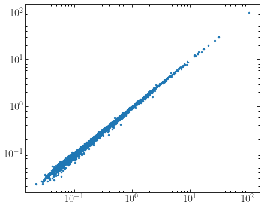

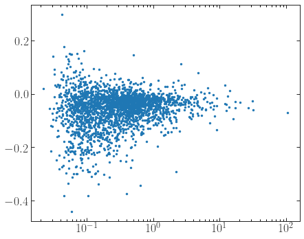

```python
loglogplot()
plt.plot(chandra_ex_lx[:,1],erosita_ex_lx[:,1],'.')

rel_err = (erosita_ex_lx[:,1] - chandra_ex_lx[:,1]) / chandra_ex_lx[:,1]

plot(semilogx=True)
plt.plot(chandra_ex_lx[:,1],rel_err,'.')

# this tells us that the chandra luminosities are basically always larger, and this should be no surprise
# since we have more pixels, we can throw out less light at the boundary

# however, i'm surprised at the percentage-level difference between the two
```